# Ciência de Dados Descritiva - Lab1 (EDA) - Checkpoint 3

# Informações iniciais

```r
dataset = read_csv(here("data/series_from_imdb.csv"),
                    progress = FALSE,
                    col_types = cols(.default = col_double(),
                                     series_name = col_character(),
                                     episode = col_character(),
                                     url = col_character(),
                                     season = col_character()))
```

Para a análise, iremos calcular a média geral de episódios e temporada para cada série e em seguida iremos selecionar as 5 melhores e as 5 piores dentre as séries selecionadas, totalizando 10 séries para a nossa análise.

As séries foram selecionadas a partir da quantidade mínima de episódios para que tenhamos uma visualização mais fácil de entender. O valor escolhido foi `total_ocurr <= 20`, onde **total_ocurr** representa a quantidade total de episódios que uma série possui.

```r
mean_series <- dataset %>%
                group_by(series_name) %>%
                summarise(media_geral = mean(user_rating),
                          total_ocurr = n()) %>%
                filter(total_ocurr %in% c(10:20)) %>%
                arrange(media_geral) %>%
                slice(c(1:5, (n() - 4): (n())))

series_imdb <- merge(mean_series, dataset) %>% arrange(media_geral)
```

Como é possível perceber na exibição abaixo:

```r
series_imdb %>% group_by(series_name) %>% distinct(series_name, media_geral)
```

| series_name | media_geral |
| --- | --- |
| How To Live With Your Parents | 6.376923 |
| Bedlam | 6.441667 |
| Are You There | 6.458333 |
| Steven Seagal: Lawman | 6.543750 |
| Dads | 6.552632 |
| Miracles | 8.823077 |
| Sherlock | 8.866667 |
| Band of Brothers | 8.880000 |
| The Last Kingdom | 8.881250 |
| Peaky Blinders | 8.883333 |

As variáveis escolhidas para alguns parâmetros de análise se comportam da seguinte maneira:

```r
series_imdb %>% select(media_geral, total_ocurr) %>% summary()
```

```
##   media_geral     total_ocurr
##  Min.   :6.377   Min.   :10.00
##  1st Qu.:6.458   1st Qu.:13.00
##  Median :7.688   Median :15.00
##  Mean   :7.676   Mean   :14.92
##  3rd Qu.:8.880   3rd Qu.:18.00
##  Max.   :8.883   Max.   :19.00
```

# Perguntas

## A quantidade de espectadores cresce/decresce ao passo que as avaliações também crescem/decrescem?

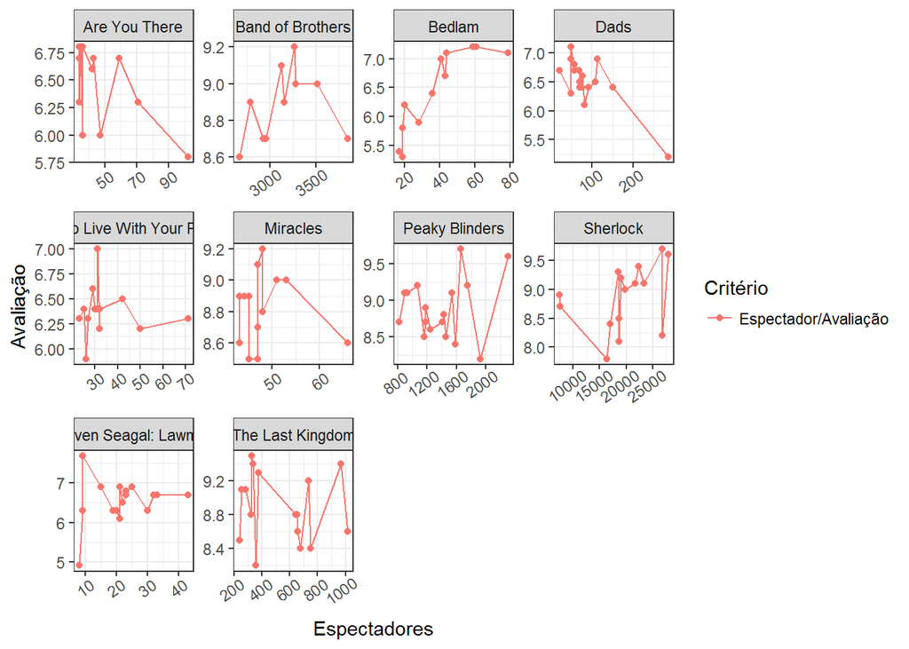

```r
series_imdb %>%
    ggplot() +
    geom_line(aes(x = user_votes, y = user_rating, color = "Espectador/Avaliação")) +
    geom_point(aes(x = user_votes, y = user_rating, color = "Espectador/Avaliação")) +
    facet_wrap(~ series_name, scales = "free") +
    labs(x = "Espectadores", y = "Avaliação",
         color = "Critério") +
    theme(axis.text.x = element_text(angle = 35, hjust = .8))
```

É possível perceber que em alguns casos essa relação entre espectadores/avaliação é clara mas em outros não, ou seja, não há uma regra ou um padrão. Em **Are You There**, por exemplo, temos que a série começa com uma nota já baixa e que ao decorrer da série há muitas irregularidades mas as ocorrências de notas baixas cresceram ao passo que o número de espectadores também cresceu, dando a entender que mais espectadores também não gostaram daquela série.

Em **Bedlam**, por exemplo, é mais fácil de perceber que aconteceu o que viemos analisar, ao passo que a quantidade de usuários aumenta, a avaliação também aumenta.

### Conclusão

Não é uma relação linear muito clara de se observar para o conjunto de dados que escolhemos e também não pode ser entendida como uma regra, apesar de termos alguns exemplos.

### Dado que não há uma relação linear, há ao menos uma relação entre as variáveis?

A quantidade de espectadores/votantes impacta na avaliação da série, isso é fácil de perceber ao obsevar o mesmo gráfico acima, a cada intervalo de votantes (ex: 10 a 20 na série **Steven Seagal: Lawman**) a avaliação sobre uma alteração, indicando que a série melhorou/piorou e foi vista com melhores/piores olhos.

## Quando o primeiro episódio da temporada possui uma nota menor que a média da temporada, a quantidade de votantes tende a cair?

Para isso, iremos colocar em um conjunto de dados as séries e suas respectivas médias por temporada:

```r
mean_season_series <- series_imdb %>%
                group_by(series_name, season) %>%
                summarise(mean_season = mean(user_rating)) %>%
                merge(series_imdb)
```

Em seguida, vamos separar outro conjunto contendo os seguites campos:

```r
series_below_mean <- series_imdb %>%
                filter(season_ep == 1) %>%
                mutate(rate_first_ep = user_rating) %>%
                select(series_name, season, user_votes, season_ep, rate_first_ep)
```

Com uma junção dos dois conjuntos, obteremos um terceiro conjunto que vai conter as séries que possuem o primeiro episódio da temporada com nota menor que a média da temporada.

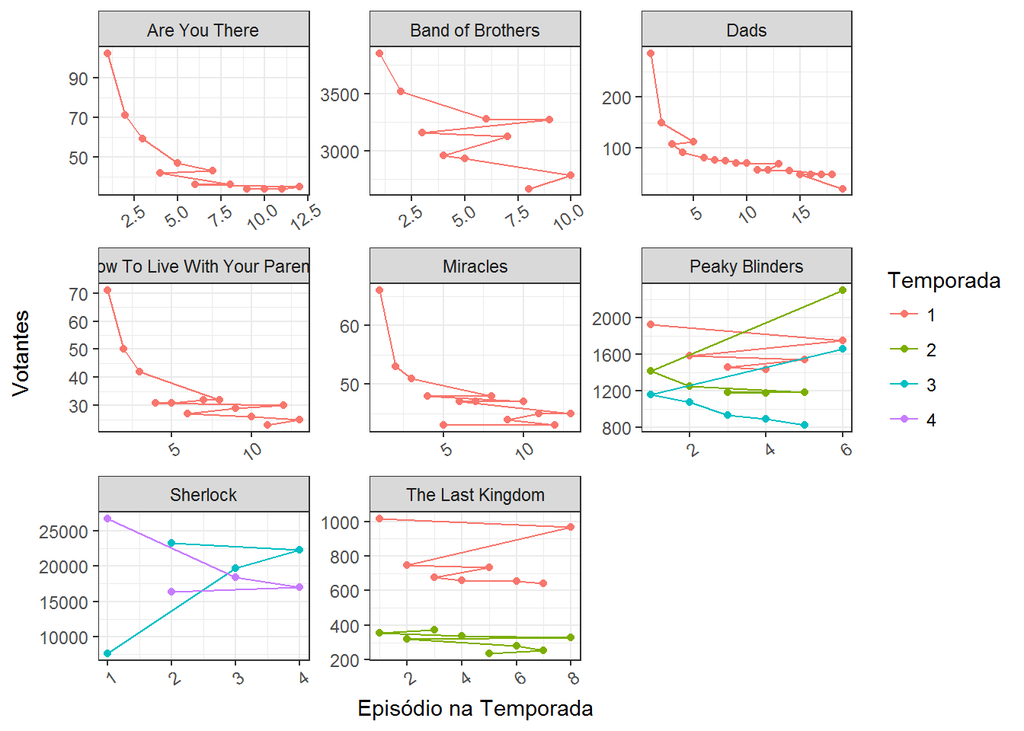

```r
filtered_series <- left_join(series_below_mean, mean_season_series,
                        by = c("series_name" = "series_name", "season" = "season")) %>%
                    filter(rate_first_ep < mean_season)

filtered_series %>%
    arrange(series_name, season_ep.y) %>%
    ggplot() +
    geom_point(aes(x = user_votes.y, y = season_ep.y, color = season)) +
    geom_line(aes(x = user_votes.y, y = season_ep.y, color = season)) +
    facet_wrap(~ series_name, scales = "free") +
    labs(x = "Votantes", y = "Episódio na Temporada",
         color = "Temporada") +
    theme(axis.text.x = element_text(angle = 35, hjust = .8)) +
    coord_flip()
```

### Conclusão

É possível perceber que geralmente uma temporada começa com menos votantes em relação a temporada anterior. As 5 primeiras séries possuem uma queda em relação a quantidade de votantes ao decorrer da série. Talvez isso aconteça porque a série não possui um primeiro episódio tão chamativo, o que faz que as pessoas desistam de assistir o restante da série.

### De outro modo, quando o primeiro episódio da temporada possui uma nota maior que a média, qual o comportamento?

Ao invés de selecionarmos as que possui nota menor, iremos selecionar de forma análoga, os que possuem nota maior que a média

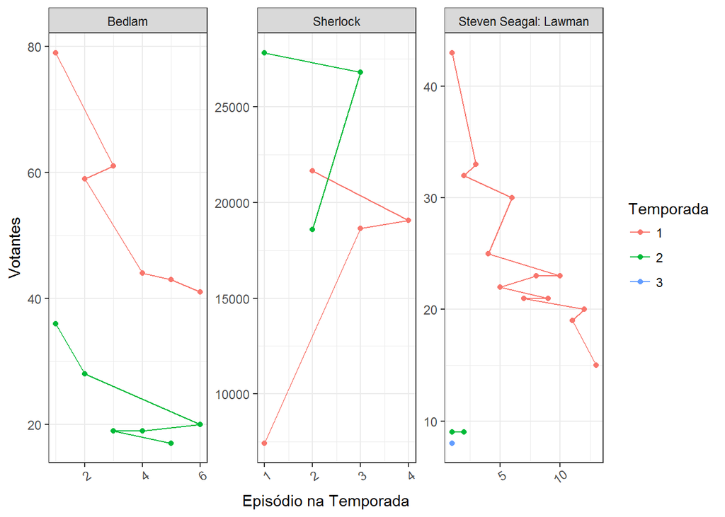

```r
filtered_series_p <- left_join(series_below_mean, mean_season_series,
                        by = c("series_name" = "series_name", "season" = "season")) %>%
                    filter(rate_first_ep >= mean_season)

filtered_series_p %>%
    arrange(series_name, season_ep.y) %>%
    ggplot() +
    geom_point(aes(x = user_votes.y, y = season_ep.y, color = season)) +
    geom_line(aes(x = user_votes.y, y = season_ep.y, color = season)) +
    facet_wrap(~ series_name, scales = "free") +
    labs(x = "Votantes", y = "Episódio na Temporada",
         color = "Temporada") +
    theme(axis.text.x = element_text(angle = 35, hjust = .8)) +
    coord_flip()
```

### Conclusão

É possível perceber que **não necessariamente** ocorre de forma análoga ao que vimos antes. Pois por exemplo, em **Sherlock** temos uma crescente na primeira temporada e em seguida, na segunda temporada (apesar de ter uma queda entre alguns episódios) mas já em **Bedlam** vemos exatamente o contrário: a primeira temporada começando com mais espectadores que a segunda temporada, a qual teve uma queda de certa forma linear onde terminou a primeira temporada na faixa de 40 votantes e começou a segunda com um pouco menos de 40, como se tivesse continuado a decair.